# Tipologia y cicle de vida de les dades: PRA2

Autor: Jaume Anguera Llort

Juny 2021

## 0.1 Objectius

● Aprendre a aplicar els coneixements adquirits i la seva capacitat de resolució de problemes en entorns nous o poc coneguts dintre de contextos més amplis o multidisciplinaris.

● Saber identificar les dades rellevants i els tractaments necessaris (integració, neteja i validació) per dur a terme un projecte analític.

● Aprendre a analitzar les dades adequadament per abordar la informació continguda en les dades.

● Identificar la millor representació dels resultats per tal d’aportar conclusions sobre el problema plantejat en el procés analític.

● Actuar amb els principis ètics i legals relacionats amb la manipulació de dades en funció de l’àmbit d’aplicació.

● Desenvolupar les habilitats d’aprenentatge que els permetin continuar estudiant d’una manera que haurà de ser en gran manera autodirigida o autònoma.

● Desenvolupar la capacitat de cerca, gestió i ús d’informació i recursos en l’àmbit de la ciència de dades.

## 0.2 Descripció del dataset. Perquè és important i quina pregunta/problema pretén respondre?

En cas aquest cas s’ha escollit el Dataset titanic. Aquest dataset té per objectiu predir o respondre la següent pregunta:

- Quins passatgers tenien més possibilitats de sobreviure? Segons siguin nens/adults, homes/dones, classe alta/baixa…

És important perquè el Titanic va ser el primer baixell en fer una travessia transoceànica a nivell recreatiu a una escala mai vista abans.

Aquest dataset és molt complet ja que recull les dades de totes les persones que van pujar a bord. El tenim divit en un conjunt d’entrenament i un conjunt de test per validar el resultat dels algorismes aplicats en l’entrenament.

Descripció dels camps del dataset:

PassengerId: Id del passatger Survived: 0 -> no, 1 -> sí Pclass: Classe del ticket, 1 = 1st, 2 = 2nd, 3 = 3rd Name: Nom del passatger Sex: Home, dona Age: Edat SibSp: Número de familiars a bord. Germà, germana, germanastre, germanastra, marit, muller. Parch: Número de pares fills a bord respecte al passatger. Pare, mare, filla, fill, fillastre, fillastra. Ticket: Número de ticket Fare: Preu o tarifa Cabin: Número de cabina Embarked: Lloc d’embarcament, C = Cherbourg, Q = Queenstown, S = Southampton

Carreguem les llibreries:

```r
  library(dplyr)
  library(ggplot2)
  library(missForest)
  library(VIM)
  library(caret)
```

Tot seguit carregarem els dos datasets.

```r
  titanic_train <- read.csv("./Dataset/train.csv", header = TRUE)
  titanic_test <- read.csv("./Dataset/test.csv", header = TRUE)


  # Mirem quines columnes té el Dataset
  head(titanic_train)
```

```
##   PassengerId Survived Pclass
## 1           1        0      3
## 2           2        1      1
## 3           3        1      3
## 4           4        1      1
## 5           5        0      3
## 6           6        0      3
##                                                  Name    Sex Age SibSp Parch
## 1                             Braund, Mr. Owen Harris   male  22     1     0
## 2 Cumings, Mrs. John Bradley (Florence Briggs Thayer) female  38     1     0
## 3                              Heikkinen, Miss. Laina female  26     0     0
## 4        Futrelle, Mrs. Jacques Heath (Lily May Peel) female  35     1     0
## 5                            Allen, Mr. William Henry   male  35     0     0
## 6                                    Moran, Mr. James   male  NA     0     0
##             Ticket    Fare Cabin Embarked
## 1        A/5 21171  7.2500              S
## 2         PC 17599 71.2833   C85        C
## 3 STON/O2. 3101282  7.9250              S
## 4           113803 53.1000  C123        S
## 5           373450  8.0500              S
## 6           330877  8.4583              Q
```

```r
  head(titanic_test)
```

```
##   PassengerId Pclass                                         Name    Sex  Age
## 1         892      3                             Kelly, Mr. James   male 34.5
## 2         893      3             Wilkes, Mrs. James (Ellen Needs) female 47.0
## 3         894      2                    Myles, Mr. Thomas Francis   male 62.0
## 4         895      3                             Wirz, Mr. Albert   male 27.0
## 5         896      3 Hirvonen, Mrs. Alexander (Helga E Lindqvist) female 22.0
## 6         897      3                   Svensson, Mr. Johan Cervin   male 14.0
##   SibSp Parch  Ticket    Fare Cabin Embarked
## 1     0     0  330911  7.8292              Q
## 2     1     0  363272  7.0000              S
## 3     0     0  240276  9.6875              Q
## 4     0     0  315154  8.6625              S
## 5     1     1 3101298 12.2875              S
## 6     0     0    7538  9.2250              S
```

Veiem que del dataset titanic_test falta la columna Survived. Té sentit ja que és la que intentarem predir posteriorment.

## 0.3 Integració i selecció de les dades d’interès a analitzar.

El nom del passatge realment no ens interessa ja que ja tenim el camp PassengerId que ve a ser el mateix. El número de ticket tampoc ens interessa ja que tampoc ens aporta informació rellevant seria gairebe igual que el PassengerID.

## 0.4 Neteja de les dades.

### 0.4.1 Les dades contenen zeros o elements buits? Com gestionaries aquests casos?

Per fer aquest estudi ajuntarem els dos datasets per no haber de repetir les operacions dues vegades.

```r
titanic_conjunt <- rbind(titanic_test, titanic_train[,c(1,3:12)])
```

Mirem valors nulls:

```r
colSums(is.na(titanic_conjunt))
```

```
## PassengerId      Pclass        Name         Sex         Age       SibSp
##           0           0           0           0         263           0
##       Parch      Ticket        Fare       Cabin    Embarked
##           0           0           1           0           0
```

Veiem que edat té 263 valors buits i Fare té un valor buit

```r
sum(titanic_conjunt$Cabin=='')
```

```
## [1] 1014
```

Per altra banda la columna cabina té un total de 1014 valors buits.

Pel que fa al tractament:

Columna Cabin. No s’utilitzarà aquesta columna. Té massa valors buits i no té sentit intentar arreglar-la. Quedaria massa artificial.

La columan Fare només té un valor buit. Al ser un únic valor es pot substituir per la mitja de total dels valors.

```r
mean(titanic_conjunt$Fare, na.rm=TRUE)
```

```
## [1] 33.29548
```

```r
# Veiem quin és el valor buit:
titanic_conjunt[!complete.cases(titanic_conjunt$Fare),]
```

```
##     PassengerId Pclass               Name  Sex  Age SibSp Parch Ticket Fare
## 153        1044      3 Storey, Mr. Thomas male 60.5     0     0   3701   NA
##     Cabin Embarked
## 153              S
```

```r
#Correspon al PassengerId=1044 fila 153

titanic_conjunt$Fare[153] <- mean(titanic_conjunt$Fare, na.rm=TRUE)
```

Pel que fa a l’edat tenim vàries maneres de procedir. Hi han moltes maneres de procedir, entre elles: Podem crear un arbre de decisió per veure cada valor què li correspondria o també podem crear una regressió lineal per predir el valor de cada un.

Primer mirem com es distribueix:

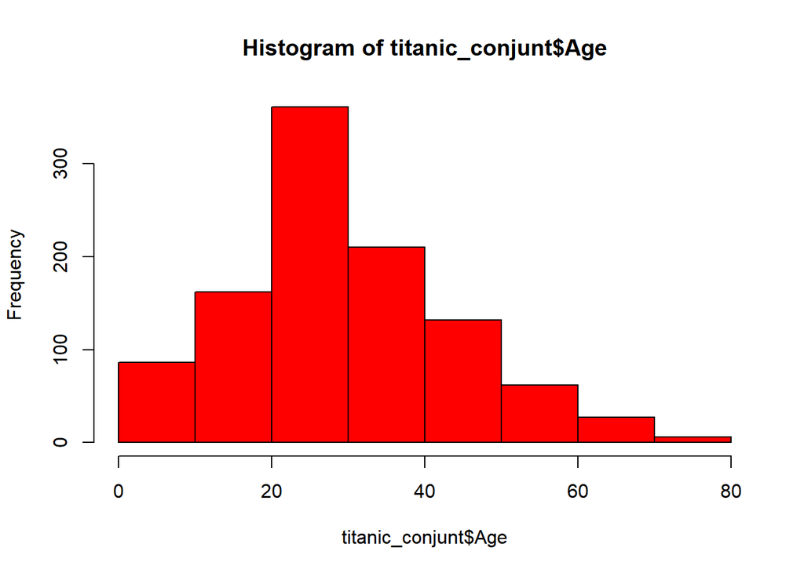

```r
titanic_conjunt$Age <- as.numeric(as.character(titanic_conjunt$Age))
hist(titanic_conjunt$Age, breaks=10, col="red")
```

Utilitzarem la llibreia missForest per imputar els valors perduts de Age

```r
titanic_net<- titanic_conjunt[,c(2,4,5,6,7,9)]


titanic_net[is.na(titanic_net)] <- ''
titanic_net$Fare <- as.numeric(as.character(titanic_net$Fare))
titanic_net$Age <- as.numeric(as.character(titanic_net$Age))


titanic_net[sapply(titanic_net, is.character)] <- lapply(titanic_net[sapply(titanic_net, is.character)], as.factor)
titanic_net$Pclass <- as.factor(titanic_net$Pclass)
titanic_net$SibSp <- as.factor(titanic_net$SibSp)
titanic_net$Parch <- as.factor(titanic_net$Parch)

sapply(titanic_net, class)
```

```
##    Pclass       Sex       Age     SibSp     Parch      Fare
##  "factor"  "factor" "numeric"  "factor"  "factor" "numeric"
```

```r
imp <- missForest(titanic_net, verbose = TRUE, variablewise = TRUE)
```

```
##   missForest iteration 1 in progress...done!
##     estimated error(s): 0 0 147.0281 0 0 0
##     difference(s): 0.001924579 0
##     time: 0.14 seconds
##
##   missForest iteration 2 in progress...done!
##     estimated error(s): 0 0 147.791 0 0 0
##     difference(s): 2.424368e-05 0
##     time: 0.14 seconds
##
##   missForest iteration 3 in progress...done!
##     estimated error(s): 0 0 146.5823 0 0 0
##     difference(s): 2.965142e-05 0
##     time: 0.16 seconds
```

```r
titanic_net <- as.data.frame(imp$ximp)
```

## 0.5 Anàlisis de les dades

### 0.5.1 Selecció dels grups de dades que es volen analitzar/comparar

En el conjunt titanic_net ja tenim les dades que voldrem analitzar amb els següents camps: - Pclass - Sex - Age - SibSp - Parch - Fare

Amb això hem eliminat columnes que no ens aportaven informació com són: - El id del passatger. - El nom del passatger. - La cabina (contenia molts valors buits i la seva reconstrucció hauria dut a un esbiaix de la prova) - El lloc d’embarcament. Realment pel que volem respondre no la necessitem. el que volem fer es saber característiques que van portar a sobreviure no d’on provenia el que va sobreviure.

### 0.5.2 Comprovació de la normalitat i homogeneïtat de la variància

Comprobació de la columna Age:

```r
ks.test(titanic_net$Age, pnorm, mean(titanic_net$Age), sd(titanic_net$Age))
```

```
##
##  One-sample Kolmogorov-Smirnov test
##
## data:  titanic_net$Age
## D = 0.10449, p-value = 7.728e-13
## alternative hypothesis: two-sided
```

```r
shapiro.test(titanic_net$Age)
```

```
##
##  Shapiro-Wilk normality test
##
## data:  titanic_net$Age
## W = 0.97354, p-value = 9.276e-15
```

Ambdues proves mostren que les dades no segueixen una distribució normal pel que fa a la columna Age.

Comprobació de la columna Fare:

```r
ks.test(titanic_net$Fare, pnorm, mean(titanic_net$Fare), sd(titanic_net$Fare))
```

```
##
##  One-sample Kolmogorov-Smirnov test
##
## data:  titanic_net$Fare
## D = 0.2858, p-value < 2.2e-16
## alternative hypothesis: two-sided
```

```r
shapiro.test(titanic_net$Fare)
```

```
##
##  Shapiro-Wilk normality test
##
## data:  titanic_net$Fare
## W = 0.52786, p-value < 2.2e-16
```

```r
# Veiem que les dades no segueixen una distribució normal
```

Comprobació de la columna SibSp:

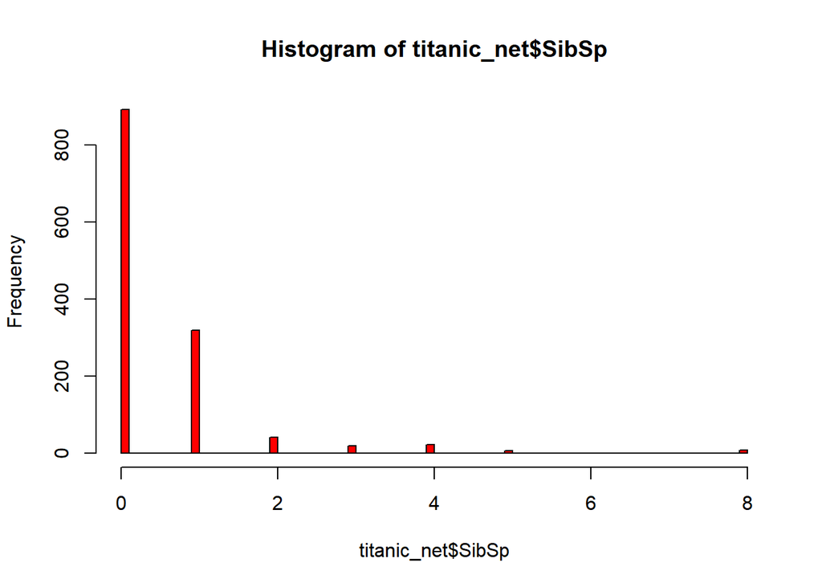

```r
titanic_net$SibSp <- as.numeric(as.character(titanic_net$SibSp))

hist(titanic_net$SibSp, breaks=100, col="red")
```

```r
ks.test(titanic_net$SibSp, pnorm, mean(titanic_net$SibSp), sd(titanic_net$SibSp))
```

```
##
##  One-sample Kolmogorov-Smirnov test
##
## data:  titanic_net$SibSp
## D = 0.36467, p-value < 2.2e-16
## alternative hypothesis: two-sided
```

```r
shapiro.test(titanic_net$SibSp)
```

```
##
##  Shapiro-Wilk normality test
##
## data:  titanic_net$SibSp
## W = 0.51108, p-value < 2.2e-16
```

```r
# Veiem que les dades no segueixen una distribució normal
```

Comprobació de l’homoscedasticitat

Com em vist anteriorment les dades no segueixen una distribució normal per tant s’ha d’utlitzar el test de Fligner-Killeen.

```r
 fligner.test(Age ~ Fare, data = titanic_net)
```

```
##
##  Fligner-Killeen test of homogeneity of variances
##
## data:  Age by Fare
## Fligner-Killeen:med chi-squared = 391.71, df = 281, p-value = 1.363e-05
```

Les dades no compleixen l’homoscedasticitat i presenten variàncies diferents.

### 0.5.3 Aplicació de proves estadístiques per comparar els grups de dades. En funció de les dades i de l’objectiu de l’estudi, aplicar proves de contrast d’hipòtesis, correlacions, regressions, etc. Aplicar almenys tres mètodes d’anàlisi diferents.

```r
# Seleccionem el conjunt original de train
titanic_train_net <- titanic_net[1:891,]

# Hi afegim la columan Survived
titanic_train_net$Survived <- titanic_train$Survived

# Normalitzem les columnes Age i Fare perquè no ens facin models esbiaixats

normalize <- function(x) {
                        return ((x - min(x)) / (max(x) - min(x)))
}

titanic_train_net$Age <- normalize(titanic_train_net$Age)
titanic_train_net$Fare <- normalize(titanic_train_net$Fare)
```

Aplicarem un model supervisat i un no supervisat per veure les diferències en els resultats

Com a model supervisat utilitzarem Randomforest.

```r
# Agafem 2/3 del dataset per entrenar i la resta per veure com funciona l'algorisme de predicció

train<- titanic_train_net[1:594,]
test<- titanic_train_net[595:891,]



set.seed(451)

model_supervisat <- randomForest(factor(Survived) ~ Pclass + Fare + Sex + Age + SibSp + Parch,
 data = train, importance = TRUE, ntree = 1000,mtry=2)

model_supervisat
```

```
##
## Call:
##  randomForest(formula = factor(Survived) ~ Pclass + Fare + Sex +      Age + SibSp + Parch, data = train, importance = TRUE, ntree = 1000,      mtry = 2)
##                Type of random forest: classification
##                      Number of trees: 1000
## No. of variables tried at each split: 2
##
##         OOB estimate of  error rate: 43.6%
## Confusion matrix:
##     0  1 class.error
## 0 290 70   0.1944444
## 1 189 45   0.8076923
```

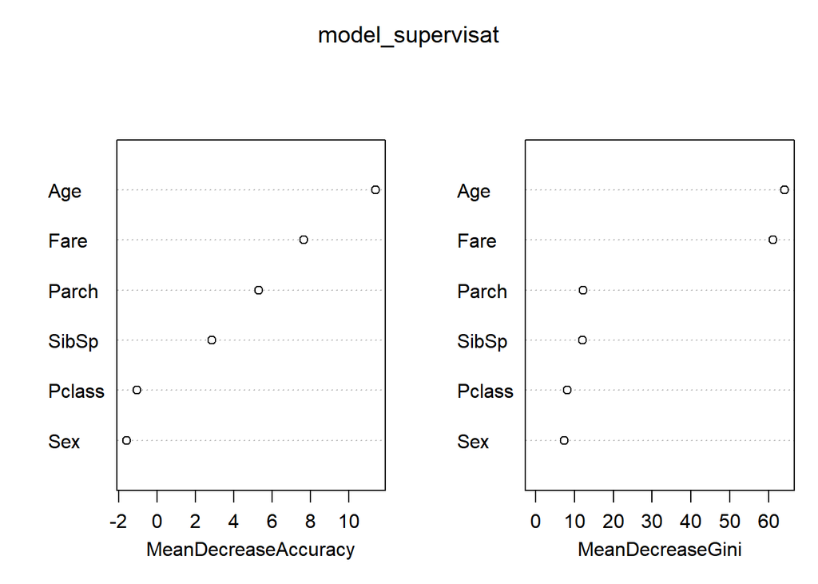

```r
varImpPlot(model_supervisat)
```

Utilitzem el model generat en l’algorisme de test:

```r
prediccio <- predict(model_supervisat, test)
```

Model no supervisat

Aplicarem l’algorisme K-means per veure quins dos grups ens genera. Com es un mètode no supervist a priori no sabem quants grups ens pot generar el model. En aquest cas específic sabem que només hi ha dos grups, els que van sobreiure i els que no.

Per tant aplicarem l’algorisme per una k = 2.

Aquí podem agafar el model sencer ja que la variable predictora no la utilitzarem

```r
titanic_train_net_num <-lapply(titanic_train_net,as.double)
titanic_train_net_num <- as.data.frame(titanic_train_net_num)


kmeans_titanic<-kmeans(titanic_train_net_num[, c(1:6)],2)
```

### 0.5.4 Representació dels resultats a partir de taules i gràfiques.

Respecte al model supervisat:

Mirem en una confusion matrix quin error ens ha donat l’algorisme generat:

```r
confusionMatrix(prediccio,as.factor(test$Survived))
```

```
## Confusion Matrix and Statistics
##
##           Reference
## Prediction   0   1
##          0 154  92
##          1  35  16
##
##                Accuracy : 0.5724
##                  95% CI : (0.514, 0.6294)
##     No Information Rate : 0.6364
##     P-Value [Acc > NIR] : 0.9901
##
##                   Kappa : -0.0418
##
##  Mcnemar's Test P-Value : 6.723e-07
##
##             Sensitivity : 0.8148
##             Specificity : 0.1481
##          Pos Pred Value : 0.6260
##          Neg Pred Value : 0.3137
##              Prevalence : 0.6364
##          Detection Rate : 0.5185
##    Detection Prevalence : 0.8283
##       Balanced Accuracy : 0.4815
##
##        'Positive' Class : 0
##
```

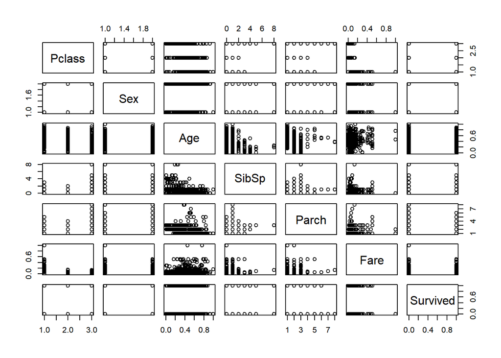

```r
plot(titanic_train_net)
```

Model no supervisat Kmeans

```r
table(titanic_train_net_num$Survived,kmeans_titanic$cluster)
```

```
##
##       1   2
##   0 421 128
##   1 274  68
```

El model supervisat en aquest cas ha funcionat millor que el no supervisat.

### 0.5.5 Resolució del problema. A partir dels resultats obtinguts, quines són les conclusions? Els resultats permeten respondre al problema?

Amb els resultats que hem obtingut amb els dos algorismes aplicats hem pogut veure que tan un com l’altre són poc precisos.

Evidentment escolliríem el model supervisat en cas d’haver-lo d’utilitzar en la vida real.

Els resultats obtinguts permeten resoldre el problema tot i que s’hauria de treballar molt més per extreure tot el potencial que té el dataset i arribar a tenir una precisió més alta.